# Sensitivity & Stability Analysis for MCDA Methods

Cagatay Cebeci

29 May 2025

# 1 Introduction

This vignette is a comprehensive tutorial on how to use test the stability and sensitivity of MCDA methods. # Required Packages The recent version of the package `mcdabench` from CRAN is installed with the following command:

```r
install.packages("mcdabench", dep=TRUE)
```

If you have already installed `mcdabench`, you can load it into R working environment by using the following command:

```r
library(mcdabench)
```

# 2 Data Set

As an example, the `egrids` dataset in the package contains simulated data representing different energy management strategies or system configurations for optimizing smart grids. The dataset includes 12 alternatives and 10 criteria, which evaluate smart grids in terms of efficiency, reliability, environmental compatibility, and cost-effectiveness.

```r
 # Load the data set
 data(egrids)

 # Extract the decision matrix, benefit-cost vector and weights
 dmat <- egrids$dmat
 bc <- egrids$bcvec
 userwei <- egrids$weights
 print(egrids)
```

```
## $dmat
##     C1 C2 C3 C4     C5  C6  C7   C8 C9  C10
## G1  85 92 88 75 0.0050 120  98 0.30 95 1.20
## G2  80 90 85 78 0.0070 115  97 0.40 93 1.50
## G3  82 88 87 70 0.0040 110  95 0.35 96 1.10
## G4  78 85 82 80 0.0060 125  99 0.25 94 1.40
## G5  90 95 92 74 0.0055 118  96 0.33 97 1.30
## G6  88 91 89 76 0.0062 112  94 0.28 92 1.40
## G7  81 89 83 79 0.0071 130 100 0.22 98 1.60
## G8  76 83 80 77 0.0065 127  98 0.29 91 1.35
## G9  89 94 90 73 0.0058 122  97 0.27 90 1.25
## G10 87 90 88 72 0.0049 108  93 0.32 89 1.18
## G11 79 84 81 75 0.0067 117  96 0.31 95 1.50
## G12 77 86 79 71 0.0053 105  91 0.26 88 1.22
##
## $bcvec
##  [1]  1  1  1  1 -1 -1 -1 -1 -1 -1
##
## $weights
##   C1   C2   C3   C4   C5   C6   C7   C8   C9  C10
## 0.15 0.12 0.10 0.08 0.07 0.13 0.10 0.08 0.12 0.05
```

# 3 Calculation of Weights

In the following code snippet, the weights are calculated applying various methods on the decision matrix.

```r
nmat <- calcnormal(dmat, bc, type="vector")
critwei <- calcweights(dmatrix=nmat, bcvec=bc, type="critic")
entwei <- calcweights(dmatrix=nmat, bcvec=bc, type="entropy")
equwei <- calcweights(dmatrix=nmat, bcvec=bc, type="equal")
giniwei <- calcweights(dmatrix=nmat,bcvec=bc, type="gini")
sdevwei <- calcweights(dmatrix=nmat, bcvec=bc, type="sdev")
merecwei <- calcweights(dmatrix=nmat, bcvec=bc, type="merec")
mpsiwei <- calcweights(dmatrix=nmat, bcvec=bc, type="mpsi")
geomwei <- calcweights(dmatrix=nmat, bcvec=bc, type="geom")
rocwei <- calcweights(dmatrix=nmat, bcvec=bc, type="roc")
rswei <- calcweights(dmatrix=nmat, bcvec=bc, type="rs")
wmatrix <- cbind(Equal=equwei, Merec=merecwei, Geometric=geomwei, Gini=giniwei,
    Critic=critwei, Mpsi=mpsiwei, Entropy=entwei, StdDev=sdevwei, Rs=rswei, Roc=rocwei )
print(round(wmatrix,3))
```

```
##     Equal Merec Geometric  Gini Critic  Mpsi Entropy StdDev    Rs   Roc
## C1    0.1 0.098     0.086 0.142  0.066 0.128   0.168  0.079 0.182 0.341
## C2    0.1 0.099     0.094 0.103  0.051 0.106   0.089  0.057 0.164 0.171
## C3    0.1 0.099     0.091 0.119  0.057 0.111   0.119  0.066 0.145 0.114
## C4    0.1 0.100     0.098 0.101  0.090 0.103   0.084  0.056 0.127 0.085
## C5    0.1 0.103     0.125 0.152  0.180 0.094   0.192  0.210 0.109 0.068
## C6    0.1 0.100     0.098 0.064  0.079 0.100   0.034  0.088 0.091 0.057
## C7    0.1 0.102     0.122 0.026  0.032 0.085   0.006  0.036 0.073 0.049
## C8    0.1 0.099     0.091 0.151  0.273 0.074   0.200  0.212 0.055 0.043
## C9    0.1 0.100     0.101 0.033  0.046 0.106   0.009  0.046 0.036 0.038
## C10   0.1 0.099     0.094 0.109  0.125 0.094   0.099  0.150 0.018 0.034
```

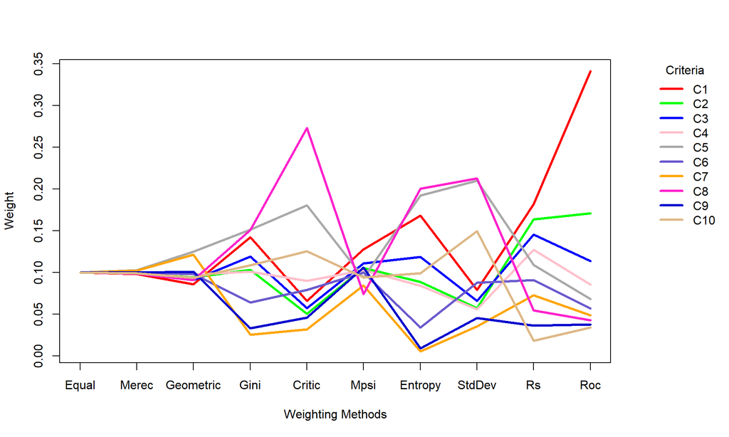

```r
parcorplot(wmatrix, xl="Weighting Methods", yl="Weight", lt="Criteria")
```

# 4 MCDA Method for Different Weights

In the following code snippet, we apply the TOPSIS (Technique for Order of Preference by Similarity to Ideal Solution) method using each of the previously calculated weight sets. his demonstrates how different weighting strategies can lead to varying rankings of alternatives.

```r
critrank <- topsis(dmatrix=dmat, bcvec=bc, weights=critwei)$rank
entrank <- topsis(dmatrix=dmat, bcvec=bc, weights=entwei)$rank
equrank <- topsis(dmatrix=dmat, bcvec=bc, weights=equwei)$rank
ginirank <- topsis(dmatrix=dmat, bcvec=bc, weights=giniwei)$rank
sdevrank <- topsis(dmatrix=dmat, bcvec=bc, weights=sdevwei)$rank
geomrank <- topsis(dmatrix=dmat, bcvec=bc, weights=geomwei)$rank
merecrank <- topsis(dmatrix=dmat, bcvec=bc, weights=merecwei)$rank
mpsirank <- topsis(dmatrix=dmat, bcvec=bc, weights=mpsiwei)$rank
rocrank <- topsis(dmatrix=dmat, bcvec=bc, weights=rocwei)$rank
rsrank <- topsis(dmatrix=dmat, bcvec=bc, weights=rswei)$rank

topsisranks <- cbind(Equal=equrank, Critic=critrank, StdDev=sdevrank, Gini=ginirank, Geometric=geomrank,
    Merec=merecrank, Mpsi=mpsirank, Entropy=entrank, Roc=rocrank, Rs=rsrank)
```

The `topsisranks` matrix, shown above, displays the resulting rankings of alternatives when TOPSIS is applied with each of the ten weighting methods. By comparing the ranks across columns, one can observe the impact of different weighting schemes on the final decision outcomes.

```r
rownames(topsisranks) <- rownames(dmat)
print(t(topsisranks))
```

```
##           G1 G2 G3 G4 G5 G6 G7 G8 G9 G10 G11 G12
## Equal      5  9  7  8  4  2 10 11  3   1  12   6
## Critic     3 12  8  4  9  6  7 10  2   5  11   1
## StdDev     2 12  4  8  6  7  9 10  5   1  11   3
## Gini       2 11  6  8  3  5  9 10  1   4  12   7
## Geometric  7  9  6  8  5  2 11 10  3   1  12   4
## Merec      5  9  7  8  4  2 10 11  3   1  12   6
## Mpsi       5  8  6  9  4  2 10 11  3   1  12   7
## Entropy    2 12  6  7  4  5  9 10  1   3  11   8
## Roc        5  8  6  9  1  3  7 12  2   4  11  10
## Rs         5  7  6  9  1  2  8 12  3   4  11  10
```

The rank heatmap provides a visual representation of the rankings. The smallest rank number (1) indicates highest (best) rank, while higher rank numbers indicate lower (worse) ranks. The heatmap allows for quick identification of alternatives that consistently rank high or low across different weighting methods, as well as those whose ranks vary considerably. The row dendrogram groups similar ranking profiles.

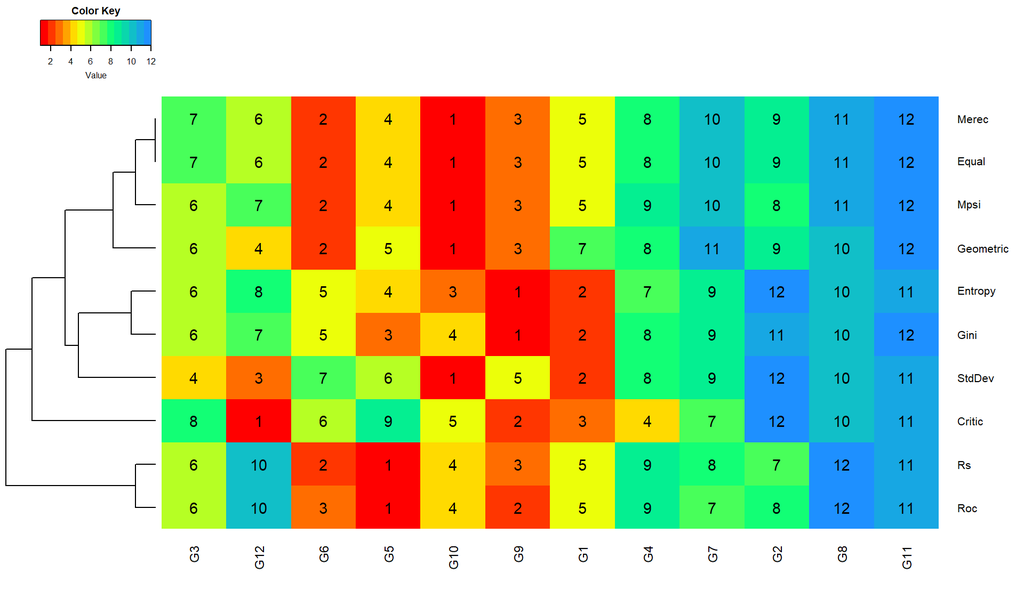

```r
rankheatmap(t(topsisranks), colpal=1, cellnotes=TRUE, tcol="black", dendro="row")
```

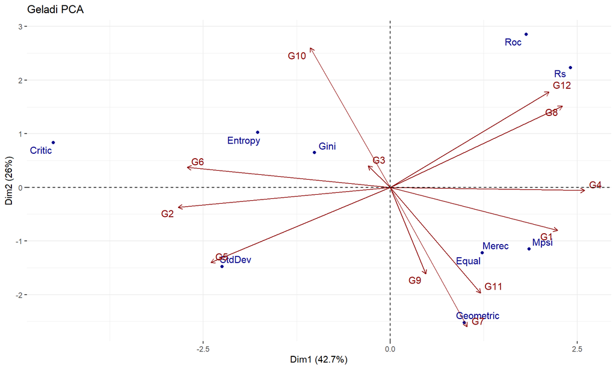

```r
pca <- rankpca(t(topsisranks), biplot=TRUE)
```

## 4.1 Sensitivity Analysis for Alternatives

```r
ressens1 <- sensana(t(topsisranks))
print(ressens1)
```

```
## $stabtable
##        G1   G2   G3   G4   G5   G6   G7   G8   G9  G10  G11  G12
## SD   1.73 1.89 1.03 1.48 2.33 1.96 1.33 0.82 1.17 1.65 0.53 2.90
## CRV  0.42 0.19 0.17 0.19 0.57 0.54 0.15 0.08 0.45 0.66 0.05 0.47
## SD2  0.13 0.15 0.06 0.08 0.14 0.16 0.09 0.06 0.08 0.14 0.05 0.20
## SRSI 0.67 0.78 0.56 0.56 0.67 0.78 0.78 0.44 0.78 0.67 0.33 0.89
## RSI  0.70 0.60 0.70 0.70 0.50 0.60 0.60 0.80 0.70 0.70 0.90 0.40
##
## $sensscores
##  G1  G2  G3  G4  G5  G6  G7  G8  G9 G10 G11 G12
## 1.3 1.5 1.0 0.8 1.5 1.6 1.2 0.7 0.8 1.5 0.5 2.2
##
## $sensscores2
##   G1   G2   G3   G4   G5   G6   G7   G8   G9  G10  G11  G12
## 1.93 2.20 1.07 1.42 2.60 2.18 1.56 0.91 1.29 1.84 0.56 3.42
```

## 4.2 Rank Comparison by the Weighting Methods

Here, we compare the rank similarities and differences between the various weighting methods using several statistical tests and similarity measures. This helps quantify how consistent or divergent the ranking outcomes are across different approaches. The `rescomp` object contains several matrices that quantify the similarity between the rankings produced by each weighting method:

```r
rescomp <- rankcompare(t(topsisranks), biplot=FALSE, nperms = 100, nboot=100,
   entropyopt = "jsd", alpha = 0.05, padjmethod = "bonferroni")
```

The **Spearman Rank Correlations matrix (src)** shows the correlation between the ranks generated by each pair of weighting methods. Higher correlation values indicate greater similarity in rankings. In the displayed matrix, the lower triangle shows the Spearman correlation coefficients, while the upper triangle displays the significance test results.

```r
print(rescomp$src) # Spearman rank correlations matrix
```

```
##           Equal Critic StdDev Gini Geometric Merec Mpsi Entropy  Roc  Rs
## Equal         1            **  ***       ***   ***  ***     ***  *** ***
## Critic     0.57      1     **    *         *                  *
## StdDev     0.75   0.73      1   **        **    **   **      **
## Gini       0.86   0.64   0.79    1        **   ***  ***     ***  ***  **
## Geometric  0.96   0.58   0.74 0.76         1   ***  ***      **    *   *
## Merec      1.00   0.57   0.75 0.86      0.96     1  ***     ***  *** ***
## Mpsi       0.99   0.46   0.71 0.85      0.94  0.99    1     ***  *** ***
## Entropy    0.85   0.66   0.80 0.98      0.74  0.85 0.83       1   **  **
## Roc        0.83   0.27   0.49 0.84      0.69  0.83 0.86    0.80    1 ***
## Rs         0.84   0.21   0.45 0.80      0.71  0.84 0.88    0.76 0.99   1
```

The **Weight Similarity matrix (wsrs)** is another measure of rank similarity, often giving more weight to highly similar ranks.

```r
print(rescomp$wsrs) # WS similarity matrix
```

```
##           Equal Critic StdDev Gini Geometric Merec Mpsi Entropy  Roc   Rs
## Equal             0.64   0.81 0.74      0.98  1.00 1.00    0.78 0.79 0.83
## Critic     0.65          0.76 0.64      0.72  0.65 0.60    0.60 0.51 0.48
## StdDev     0.84   0.71        0.76      0.83  0.84 0.83    0.80 0.64 0.65
## Gini       0.78   0.82   0.73           0.71  0.78 0.78    0.98 0.84 0.79
## Geometric  0.97   0.65   0.82 0.72            0.97 0.97    0.76 0.76 0.79
## Merec      1.00   0.64   0.81 0.74      0.98       1.00    0.78 0.79 0.83
## Mpsi       1.00   0.64   0.81 0.74      0.98  1.00         0.79 0.80 0.84
## Entropy    0.79   0.84   0.76 0.98      0.73  0.79 0.79         0.83 0.78
## Roc        0.79   0.57   0.59 0.84      0.74  0.79 0.80    0.78      0.96
## Rs         0.83   0.49   0.57 0.79      0.78  0.83 0.84    0.73 0.96
```

The **Wilcoxon Rank Sum Test (wilcox)** matrix provides p-values from pairwise Wilcoxon tests, indicating whether there’s a statistically significant difference between the ranks generated by two methods. In the displayed matrix, the lower triangle shows the test statistic (W), while the upper triangle displays the adjusted p-values for the statistical inference.

```r
print(rescomp$wilcox) # Wilcox test matrix
```

```
##           Equal Critic StdDev  Gini Geometric Merec  Mpsi Entropy  Roc   Rs
## Equal             1.00   1.00  1.00      1.00   NaN  1.00    1.00 1.00 1.00
## Critic    39.50          1.00  1.00      1.00  1.00  1.00    1.00 1.00 1.00
## StdDev    28.50  23.00         1.00      1.00  1.00  1.00    1.00 1.00 1.00
## Gini      27.50  35.50  18.00            1.00  1.00  1.00    1.00 1.00 1.00
## Geometric 10.50  33.00  22.50 20.50            1.00  1.00    1.00 1.00 1.00
## Merec      0.00  38.50  26.50 27.50     10.50        1.00    1.00 1.00 1.00
## Mpsi       5.00  39.00  32.50 22.50     15.00  5.00          1.00 1.00 1.00
## Entropy   32.00  24.00  14.00 10.50     26.00 32.00 28.00         1.00 1.00
## Roc       34.00  23.00  36.00 27.50     34.50 34.00 18.00   28.50      1.00
## Rs        23.50  32.50  32.50 27.00     24.00 23.50 14.00   27.50 5.00
```

The **Rank entropy differences matrix with permutations (entper)** and **Rank Jensen-Shannon entropy divergence (JSD) matrix with bootstrap (entboot)** are the matrices assess the uncertainty or dispersion of ranks, providing insights into the overall stability of the ranking system under permutation and bootstrap resampling.

In the displayed matrix, the lower triangle shows the Shannon entroyp differences, while the upper triangle presents the adjusted p-values for the statistical inference.

```r
print(rescomp$entper) # Rank entropy matrix with permutations
```

```
##           Equal Critic StdDev Gini Geometric Merec Mpsi Entropy  Roc   Rs
## Equal             0.94   1.00 0.99      1.00  1.00 1.00    1.00 1.00 1.00
## Critic     0.49          1.00 0.98      0.91  0.98 0.91    0.99 0.79 0.74
## StdDev     0.23   0.34        0.98      1.00  1.00 1.00    1.00 0.88 0.87
## Gini       0.26   0.38   0.32           0.99  1.00 1.00    1.00 1.00 0.98
## Geometric  0.03   0.45   0.23 0.34            1.00 1.00    0.98 0.99 1.00
## Merec      0.00   0.49   0.23 0.26      0.03       1.00    0.99 1.00 0.99
## Mpsi       0.01   0.56   0.25 0.27      0.04  0.01         1.00 1.00 0.99
## Entropy    0.24   0.37   0.29 0.01      0.32  0.24 0.25         1.00 1.00
## Roc        0.25   0.67   0.54 0.19      0.35  0.25 0.23    0.23      1.00
## Rs         0.23   0.73   0.56 0.26      0.33  0.23 0.21    0.30 0.02
```

In the displayed matrix, the lower triangle shows the Jensen-Shannon Divergence (JSD) values, while the upper triangle presents the adjusted p-values for the statistical inference.

```r
print(rescomp$entboot) # Rank entropy matrix with bootstrap
```

```
##           Equal Critic StdDev  Gini Geometric Merec  Mpsi Entropy   Roc    Rs
## Equal            1.000  1.000 1.000     1.000 1.000 1.000   1.000 1.000 1.000
## Critic    0.508         1.000 1.000     1.000 1.000 1.000   1.000 1.000 1.000
## StdDev    0.771  0.660        1.000     1.000 1.000 1.000   1.000 1.000 1.000
## Gini      0.739  0.625  0.679           1.000 1.000 1.000   1.000 1.000 1.000
## Geometric 0.972  0.547  0.769 0.660           1.000 1.000   1.000 1.000 1.000
## Merec     1.000  0.508  0.771 0.739     0.972       1.000   1.000 1.000 1.000
## Mpsi      0.993  0.444  0.755 0.734     0.959 0.993         1.000 1.000 1.000
## Entropy   0.761  0.631  0.710 0.985     0.681 0.761 0.754         1.000 1.000
## Roc       0.748  0.329  0.459 0.807     0.652 0.748 0.766   0.766       1.000
## Rs        0.767  0.270  0.436 0.741     0.673 0.767 0.788   0.698 0.981
```

# 5 Sensitivity Analysis with Gradually Modified Weighting

This section delves into a more detailed sensitivity analysis by gradually modifying a specific set of weights and observing the impact on alternative rankings. This allows for a deeper understanding of how subtle changes in criterion importance can affect the final decision. The `weisana` function performs a gradual sensitivity analysis. Here, we are incrementally perturbing the critwei (Critic method weights) by a rp (relative perturbation) factor ranging from 0.01 to 0.5. In the output below: * `gradweimat` shows the modified weight sets generated during this gradual perturbation. * `rankmat` presents the corresponding alternative rankings for each of these modified weight sets. * `topsisgrawei$sensitivity_table` summarizes the sensitivity of each alternative’s rank to these gradual changes in weights, often showing how many times an alternative’s rank changed its position, or its average rank change.

```r
mp <- list()
wp <- list(rp = seq(0.01, 0.5, 0.05))
topsisgrawei <- weisana(dmatrix = dmat, bcvec = bc, weights=critwei,
     weimethod = "gradual", weipars = wp,
     mcdamethod = topsis, methodpars = mp)
```

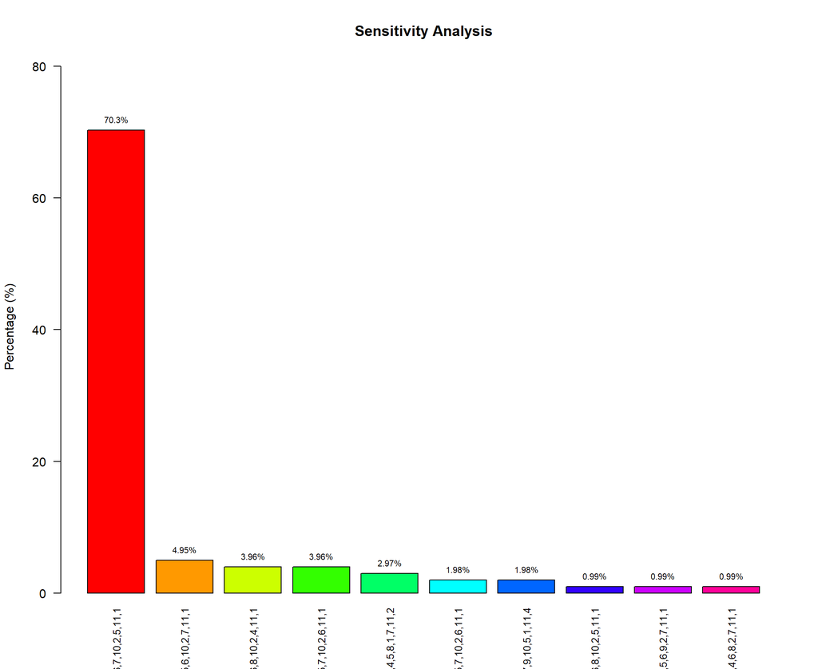

```r
str(topsisgrawei)
```

```
## List of 4
##  $ computing_time   : 'difftime' num 0.04
##   ..- attr(*, "units")= chr "secs"
##  $ weights_matrix   : num [1:101, 1:10] 0.0659 0.0652 0.0619 0.0586 0.0553 ...
##   ..- attr(*, "dimnames")=List of 2
##   .. ..$ : chr [1:101] "init" "C1-1%" "C1-6%" "C1-11%" ...
##   .. ..$ : chr [1:10] "C1" "C2" "C3" "C4" ...
##  $ ranking_matrix   : num [1:101, 1:12] 3 3 3 3 3 3 3 3 3 3 ...
##   ..- attr(*, "dimnames")=List of 2
##   .. ..$ : chr [1:101] "init" "C1-1%" "C1-6%" "C1-11%" ...
##   .. ..$ : chr [1:12] "G1" "G2" "G3" "G4" ...
##  $ sensitivity_table:'data.frame':   17 obs. of  3 variables:
##   ..$ Pattern: chr [1:17] "3,12,8,4,9,6,7,10,2,5,11,1" "3,12,7,4,9,6,8,10,2,5,11,1" "3,12,7,5,9,6,8,10,2,4,11,1" "3,12,8,4,9,5,7,10,2,6,11,1" ...
##   ..$ Count  : int [1:17] 71 1 4 2 4 5 1 1 1 3 ...
##   ..$ Percent: num [1:17] 70.3 0.99 3.96 1.98 3.96 4.95 0.99 0.99 0.99 2.97 ...
```

```r
gradweimat <- topsisgrawei$weights_matrix # Modified weights matrix
rankmat <- topsisgrawei$ranking_matrix    # Ranking matrix
senstable <- topsisgrawei$sensitivity_table # Different rankings summary table
head(round(gradweimat, 3))
```

```
##           C1    C2    C3    C4    C5    C6    C7    C8    C9   C10
## init   0.066 0.051 0.057 0.090 0.180 0.079 0.032 0.273 0.046 0.125
## C1-1%  0.065 0.051 0.057 0.090 0.181 0.079 0.032 0.273 0.046 0.125
## C1-6%  0.062 0.051 0.058 0.090 0.181 0.080 0.032 0.274 0.046 0.126
## C1-11% 0.059 0.051 0.058 0.091 0.182 0.080 0.032 0.275 0.046 0.126
## C1-16% 0.055 0.051 0.058 0.091 0.182 0.080 0.032 0.276 0.047 0.127
## C1-21% 0.052 0.052 0.058 0.091 0.183 0.081 0.032 0.277 0.047 0.127
```

```r
head(rankmat)  # Rank matrix
```

```
##        G1 G2 G3 G4 G5 G6 G7 G8 G9 G10 G11 G12
## init    3 12  8  4  9  6  7 10  2   5  11   1
## C1-1%   3 12  8  4  9  6  7 10  2   5  11   1
## C1-6%   3 12  8  4  9  6  7 10  2   5  11   1
## C1-11%  3 12  8  4  9  6  7 10  2   5  11   1
## C1-16%  3 12  8  4  9  6  7 10  2   5  11   1
## C1-21%  3 12  8  4  9  6  7 10  2   5  11   1
```

```r
print(senstable)
```

```
##                               Pattern Count Percent
## Ranking_1  3,12,8,4,9,6,7,10,2,5,11,1    71   70.30
## Ranking_2  3,12,7,4,9,6,8,10,2,5,11,1     1    0.99
## Ranking_3  3,12,7,5,9,6,8,10,2,4,11,1     4    3.96
## Ranking_4  3,12,8,4,9,5,7,10,2,6,11,1     2    1.98
## Ranking_5  4,12,8,3,9,5,7,10,2,6,11,1     4    3.96
## Ranking_6  4,12,8,3,9,5,6,10,2,7,11,1     5    4.95
## Ranking_7  4,12,8,3,10,5,6,9,2,7,11,1     1    0.99
## Ranking_8  5,12,9,3,10,4,6,8,2,7,11,1     1    0.99
## Ranking_9  5,12,10,3,9,4,6,8,1,7,11,2     1    0.99
## Ranking_10 6,12,10,3,9,4,5,8,1,7,11,2     3    2.97
## Ranking_11 2,12,6,5,9,7,8,10,3,4,11,1     1    0.99
## Ranking_12 2,12,5,6,8,7,9,10,3,4,11,1     1    0.99
## Ranking_13 1,12,5,6,8,7,9,10,4,3,11,2     1    0.99
## Ranking_14 1,12,4,6,8,7,9,10,5,2,11,3     1    0.99
## Ranking_15 1,12,3,8,6,7,9,10,5,2,11,4     1    0.99
## Ranking_16 2,12,3,8,6,7,9,10,5,1,11,4     2    1.98
## Ranking_17 3,12,2,8,6,7,9,10,5,1,11,4     1    0.99
```

The table, labeled `senstable`, provides a detailed breakdown of the different ranking patterns observed during the sensitivity analysis where criterion weights were gradually modified.

In summary, the sensitivity analysis reveals that the ranking of alternatives is quite stable, with one specific order consistently emerging as the preferred outcome across various weight modifications. However, the presence of numerous other low-frequency ranking patterns underscores that the decision is not entirely immune to changes in criterion importance, and minor perturbations can, in some cases, lead to different alternative orderings. This information is crucial for decision-makers to assess the robustness of their final choice.

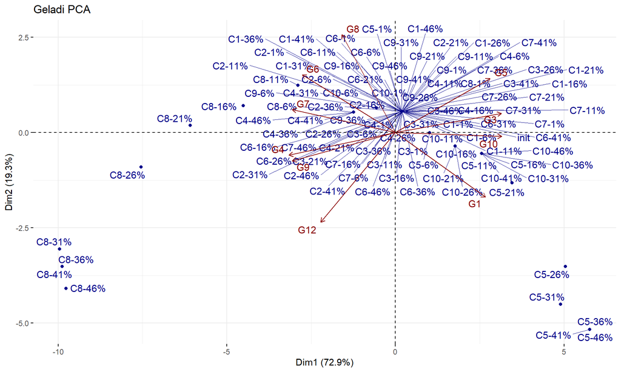

```r
pca <- rankpca(rankmat, biplot=TRUE)
```

This PCA biplot, derived from the rankmat (rankings under gradual weight modification), offers a visual summary of how the rankings evolve as the weights are gradually changed. It can highlight thresholds where small weight changes lead to significant shifts in rankings, or identify periods of high stability. The PCA biplot visualizes the relationships between the different states of gradually modified weights (represented by the blue labels like C1-46%, C1-41%, etc., where ‘C’ likely refers to a criterion and the percentage to its perturbation level) and the alternatives (represented by red text. The two dimensions, Dim1 and Dim2, capture 72.9% and 19.3% of the total variance, respectively, meaning they collectively explain a high proportion of the variability in the ranking data.

There’s a noticeable spread along Dim1, especially towards the right (e.g., C5-26% to C5-46%) and to the far left (C8-31% to C8-46%). This indicates that certain weight modifications, particularly those involving C5 and C8, lead to significantly different ranking outcomes compared to the central cluster.

Criterion 5 (C5): The labels like “C5-26%”, “C5-31%”, “C5-36%”, “C5-41%”, “C5-46%” are grouped on the far right side of Dim1. This suggests that as the weight of Criterion 5 is perturbed (especially at higher percentages like 26% to 46%), it drives the rankings to a distinct outcome, differing significantly from the rankings observed with other criterion perturbations. The vector for C5 (implied by the cluster of C5 points) would point towards the right.

Criterion 8 (C8): Similarly, the labels “C8-26%”, “C8-31%”, “C8-36%”, “C8-41%”, “C8-46%” are clustered on the far left side of Dim1, and some also spread vertically along Dim2. This indicates that perturbations of Criterion 8’s weight lead to another set of distinct rankings, significantly different from the C5-driven rankings and the central cluster.

The PCA biplot effectively visualizes the stability and sensitivity zones for the alternative rankings. It shows that while many gradual weight modifications result in similar rankings (the central cluster), certain criteria (notably C5 and C8, as indicated by their spread on the plot) have a strong influence. ## Sensitivity of Alternatives

Building on the gradual sensitivity analysis, this section provides a specific stability assessment of alternatives under these progressively modified weights

```r
ressens2 <- sensana(rankmat)
print(ressens2$stabtable)
```

```
##        G1 G2   G3   G4   G5   G6   G7   G8   G9  G10 G11  G12
## SD   0.77  0 1.28 0.97 0.63 0.62 0.73 0.44 0.73 1.12   0 0.64
## CRV  0.25  0 0.17 0.24 0.07 0.11 0.10 0.04 0.34 0.22   0 0.54
## SD2  0.04  0 0.06 0.05 0.03 0.04 0.03 0.02 0.03 0.05   0 0.03
## SRSI 0.09  0 0.12 0.09 0.05 0.06 0.09 0.03 0.06 0.12   0 0.06
## RSI  0.95  1 0.92 0.96 0.97 0.97 0.96 0.98 0.96 0.94   1 0.97
```

The `ressens2$stabtable` output provides the stability of each alternative’s rank under the influence of the gradually modified weights. This table is crucial for identifying which alternatives are robust to minor perturbations in criterion importance and which ones are highly sensitive, potentially leading to different decisions based on slight variations in expert judgment or data.

## 5.1 Decision Making with Rank Aggregation

Finally, we explore how to synthesize the diverse rankings obtained from different weighting methods into a single, more robust preference order. This is achieved through rank aggregation techniques.

The rankaggregate function combines the individual rankings from topsisranks into a single, aggregated ranking. This aggregation step is vital for deriving a more consensual and robust decision, especially when multiple legitimate weighting approaches yield different results.

- `prefrank` displays the final aggregated ranking of the alternatives. This is often considered a more stable and reliable ranking as it mitigates the influence of any single weighting method.
- `preftable` provides a more detailed breakdown, showing how each alternative performed across the different aggregated rankings, potentially including information on how many times an alternative ranked in the top k positions.

```r
respref <- rankaggregate(t(topsisranks), topk=1, tiesmethod="average")
preftable <- respref$preference_table
prefrank <- respref$preference_ranking
print(prefrank)
```

```
##           G1   G2  G3  G4  G5  G6  G7   G8  G9 G10  G11 G12
## TOPK1    8.5  8.5 8.5 8.5 2.5 8.5 8.5  8.5 2.5   1  8.5 4.0
## RANKSUM  4.5 10.0 6.5 8.0 4.5 3.0 9.0 11.0 2.0   1 12.0 6.5
## MEDIAN   5.0  9.5 6.0 8.0 4.0 2.0 9.5 11.0 3.0   1 12.0 7.0
## BORDACNT 4.5 10.0 6.5 8.0 4.5 3.0 9.0 11.0 2.0   1 12.0 6.5
## COPELAND 5.0  9.5 6.5 8.0 4.0 3.0 9.5 11.0 2.0   1 12.0 6.5
## KEMYNG   5.0  9.5 6.5 8.0 4.0 3.0 9.5 11.0 2.0   1 12.0 6.5
## MARKOV   5.0 10.0 7.0 8.0 4.0 3.0 9.0 11.0 2.0   1 12.0 6.0
```

```r
print(preftable)
```

```
##     Method                                                   Outranking
## 1    TOPK1 G10 > G5 = G9 > G12 > G1 = G2 = G3 = G4 = G6 = G7 = G8 = G11
## 2  RANKSUM G10 > G9 > G6 > G1 = G5 > G3 = G12 > G4 > G7 > G2 > G8 > G11
## 3   MEDIAN G10 > G6 > G9 > G5 > G1 > G3 > G12 > G4 > G2 = G7 > G8 > G11
## 4 BORDACNT G10 > G9 > G6 > G1 = G5 > G3 = G12 > G4 > G7 > G2 > G8 > G11
## 5 COPELAND G10 > G9 > G6 > G5 > G1 > G3 = G12 > G4 > G2 = G7 > G8 > G11
## 6   KEMYNG G10 > G9 > G6 > G5 > G1 > G3 = G12 > G4 > G2 = G7 > G8 > G11
## 7   MARKOV G10 > G9 > G6 > G5 > G1 > G12 > G3 > G4 > G7 > G2 > G8 > G11
```